# Reproducible Research

## Module 2 Course Project 1

The below code loads the Activity monitoring dataset set and saves into a vector called data

```r
data <- read.csv("activity.csv")
```

I will use dplyr, tidyr and ggplot2 during the anaysis and I will set the locale to be in english

```r
library(ggplot2)
library(dplyr)
library(tidyr)
Sys.setlocale(locale = "en")
```

```
## [1] "LC_COLLATE=en;LC_CTYPE=en;LC_MONETARY=en;LC_NUMERIC=C;LC_TIME=en"
```

### What is the mean total number of steps taken per day?

I filter the date so I only have values that are not na. I then group the data by date. Finally I summarize the the steps resulting in a tibble containing the data and the total steps on that date. This is saved in the variable daily.

```r
daily <- data %>% filter(!is.na(steps)) %>% group_by(date) %>% summarise(dailysteps = sum(steps))
```

Here is a histogram showing the number of steps per day.

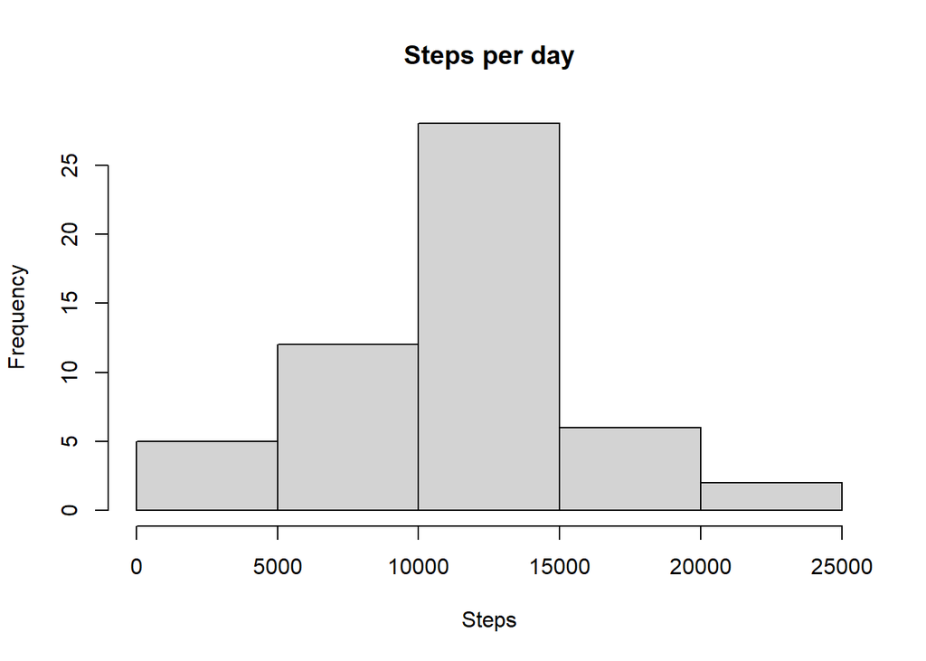

```r
hist(daily$dailysteps, main = "Steps per day", xlab = "Steps")
```

Here is the mean number of steps per day.

```r
mean(daily$dailysteps)
```

```
## [1] 10766.19
```

Here is the median number of steps per day.

```r
median(daily$dailysteps)
```

```
## [1] 10765
```

### What is the average daily activity pattern?

Here is a time series plot showing the steps per 5 minute interval and the average number of steps taken. I have excluded NA values.

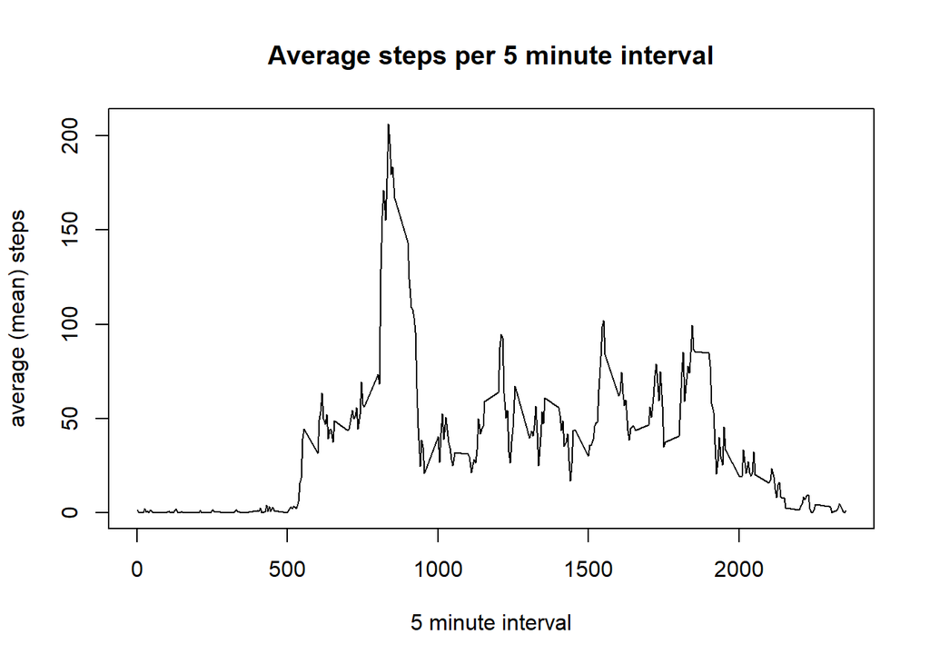

```r
#calculate the avreage steps for each interval
Intervalsteps <- data %>% filter(steps >= 0) %>% group_by(interval) %>% summarise(avgsteps = mean(steps))

#make plot
with(Intervalsteps, plot(interval,avgsteps,type="l",main="Average steps per 5 minute interval", xlab = "5 minute interval", ylab = "average (mean) steps"))
```

Below we can see from the below that the 5-minute interval with maximum number of steps on average.

```r
#Arrange Intervalstep so the interval with the higest avg is first
maxavgsteps <- Intervalsteps %>% arrange(desc(avgsteps)) %>% Intervalsteps$interval[1]

#Return the interval with the maximum number of steps
maxavgsteps$interval[1]
```

[output not shown]

### Handling the missing values in the data

Below we calculate the number of missing values in the dataset

```r
sum(is.na(data$steps))
```

```
## [1] 2304
```

Below we replace the NA values with the mean value for the given interval. I will round the mean value.

```r
#Calulate avg steps per interval and add to a new column. Filter steps to return NA values and replace the NA values with the avg steps
FixNA <- data %>% group_by(interval) %>% mutate(avgsteps = as.integer(round(mean(steps, na.rm=TRUE)))) %>% filter(is.na(steps))%>% mutate(steps = avgsteps) %>% select(steps,date,interval) %>% ungroup(interval)

#Data frame containing the
NotNA <- data %>% filter(!is.na(steps))

#Combine both data frames resulting in a data frame with no na values
NoNAdata <- rbind(NotNA,FixNA)
```

Here is a histogram based on the data set with the replaced na values. The peak at the mean is increased as the mean values occur more frequently because the na values were replaced by the mean values.

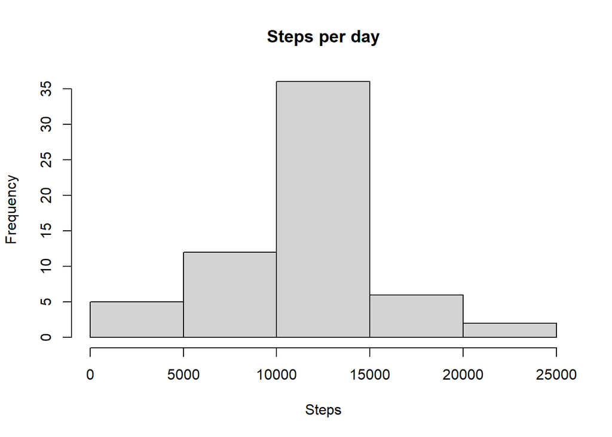

```r
#Get daily steps
dailynoNA<- NoNAdata %>% group_by(date) %>% summarise(dailysteps = sum(steps))

#Make histogram
hist(dailynoNA$dailysteps, main = "Steps per day", xlab = "Steps")
```

Here is the mean number of steps per day with the replaced values. The mean is slightly lower as there are now more days within the data set.

```r
mean(dailynoNA$dailysteps)
```

```
## [1] 10765.64
```

Here is the median number of steps per day with the replaced values. The median is slightly lower now the NA values were replaced.

```r
median(dailynoNA$dailysteps)
```

```
## [1] 10762
```

The impact of imputing missing data using the mean means that mean is emphasised in the data.

### Are there differences in activity patterns between weekdays and weekends?

Below we identify the weekday for each date and then add identifying if the day a weekend of weekday.

Here is panel plot comparing average steps per 5 min interval on weekends with weekdays. We can see that there is a higher average activity throughout the day in weekends. For weekdays we see a spike early in the day but lower activity during the rest of the day.

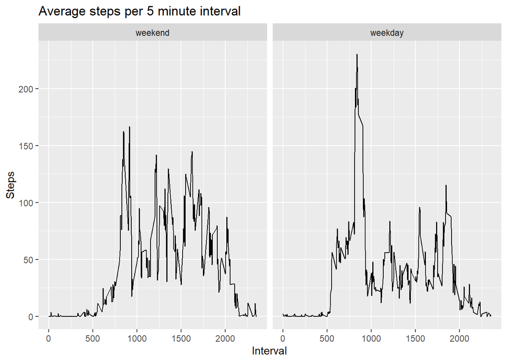

```r
#identify if a day was a weekday or weekend
dataday <- NoNAdata %>% mutate(weekday = weekdays((as.Date(date)))) %>% mutate(daytype = if_else(weekday == "Saturday" | weekday == "Sunday" , "weekend", "weekday"))

#get avg steps per interval in weekends
weekendsteps <- dataday %>% filter(daytype == "weekend") %>% group_by(interval) %>% summarise(avgsteps = mean(steps)) %>% mutate(daytype = as.factor("weekend"))

#get avg steps per interval in weekdays
weekdaysteps <- dataday %>% filter(daytype == "weekday") %>% group_by(interval) %>% summarise(avgsteps = mean(steps)) %>% mutate(daytype = as.factor("weekday"))

#Make dataframe with avg steps per interval for weekends and weekdays
wewdintsteps <- rbind(weekendsteps,weekdaysteps)

#draw plot
g <- ggplot(wewdintsteps, aes(x=interval, y=avgsteps))
p <- g+geom_line()+facet_grid(.~daytype)+labs(title = "Average steps per 5 minute interval", x = "Interval", y = "Steps")
print(p)
```